# Data wrangling - HELPrct

Week 5 Activity

Author 1 and Author 2

```r
# Good practice - clear the working environment
rm(list = ls())

# Load required packages
library(tidyverse)  # for data verbs such as group-by() & summarise()
library(mosaicData) # includes the HELPrct data set
library(esquisse)   # includes the esquisser() interactive plot builder seen in Week 4

# Load the HELPrct data from mosaicData package into our RStudio environment
data("HELPrct", package = "mosaicData")

# Use View(HELPrct) in the console to open a tab in RStudio and look at the raw data directly
```

## Data Description

*TASK 1: Write a couple of sentences describing the `HELPrct` data. What is the setting for the data? What are they about?*

[hint: you can use the help in RStudio here since the data were loaded from an R package]

```r
help(HELPrct)
```

```
## starting httpd help server ... done
```

The ‘HELPrct’ data are collected form a total of 453 patients from a detoxification unit. Variables involve physical and mental health factors, with a focus on the patients’ use of drugs (alcohol, cocaine, heroin) and their treatment.

## Basic Summaries with `summarise()`

*TASK 2: Produce an expression involving `summarize()` and `HELPrct` that will produce the following.*

1. *number of people (cases) in `HELPrct` study*
2. *combined total number of times in the past 6 months all the people in `HELPrct` entered a detox program (measured at baseline)*
3. *mean time (in days) to first use of any substance post-detox for all the people in `HELPrct`*

```r
# 1.
HELPrct %>%
  summarise(n())
```

| n() |
| --- |
| 453 |

```r
# 2.
HELPrct %>%
  summarise(sum(e2b, na.rm=TRUE))
```

| sum(e2b, na.rm = TRUE) |
| --- |
| 536 |

```r
# 3.
HELPrct %>%
  summarise(mean(daysanysub, na.rm=TRUE))
```

| mean(daysanysub, na.rm = TRUE) |
| --- |
| 75.30738 |

## Subgrouping with `group_by()`

*TASK 3: Repeat Task 2 above, but calculate the results group-by-group. Show your code and write a sentence or two about what you observe in the results for each of the following:*

1. *males versus females*

```r
# males versus females
HELPrct %>%
  group_by(sex) %>%
  summarise(n(), sum(e2b, na.rm=TRUE), mean(daysanysub, na.rm=TRUE))
```

| sex | n() | sum(e2b, na.rm = TRUE) | mean(daysanysub, na.rm = TRUE) |
| --- | --- | --- | --- |
| female | 107 | 89 | 83.77193 |
| male | 346 | 447 | 72.72727 |

It is apparent that substance abuse is much more common among males than females (or they are just seeking detox more), and although their time to use since detox is fairly close, males still generally appear to relapse sooner.

2. *homeless or not*

```r
# homeless or not
HELPrct %>%
  group_by(homeless) %>%
  summarise(n(), sum(e2b, na.rm=TRUE), mean(daysanysub, na.rm=TRUE))
```

| homeless | n() | sum(e2b, na.rm = TRUE) | mean(daysanysub, na.rm = TRUE) |
| --- | --- | --- | --- |
| homeless | 209 | 379 | 74.33051 |
| housed | 244 | 157 | 76.22222 |

The homeless and housed appear to be close in numbers, although we see slightly more housed than homeless. Though, the homeless enter more than twice the number of detox programs than the housed.

3. *substance*

```r
# substance
HELPrct %>%
  group_by(substance) %>%
  summarise(n(), sum(e2b, na.rm=TRUE), mean(daysanysub, na.rm=TRUE))
```

| substance | n() | sum(e2b, na.rm = TRUE) | mean(daysanysub, na.rm = TRUE) |
| --- | --- | --- | --- |
| alcohol | 177 | 237 | 79.36170 |
| cocaine | 152 | 96 | 85.86517 |
| heroin | 124 | 203 | 53.65574 |

Alcohol appears to have the most cases in this study, though cocaine s not far behind, with heroin not far behind it too. It looks like cocaine users tend not to seek detoxification nearly as much as those addicted to alcohol or heroin. It also appears that a heroin user is more likely to relapse sooner than a user of the other two drugs.

4. *break down the homeless versus housed further, by sex*

```r
# homeless versus housed broken down by sex
HELPrct %>%
  group_by(homeless, sex) %>%
  summarise(n(), sum(e2b, na.rm=TRUE), mean(daysanysub, na.rm=TRUE))
```

| homeless | sex | n() | sum(e2b, na.rm = TRUE) | mean(daysanysub, na.rm = TRUE) |
| --- | --- | --- | --- | --- |
| homeless | female | 40 | 41 | 82.45455 |
| homeless | male | 169 | 338 | 72.46875 |
| housed | female | 67 | 48 | 84.60000 |
| housed | male | 177 | 109 | 73.00000 |

5. *break down the homeless versus housed further, by substance*

```r
# homeless versus housed broken down by substance
HELPrct %>%
  group_by(homeless, substance) %>%
  summarise(n(), sum(e2b, na.rm=TRUE), mean(daysanysub, na.rm=TRUE))
```

| homeless | substance | n() | sum(e2b, na.rm = TRUE) | mean(daysanysub, na.rm = TRUE) |
| --- | --- | --- | --- | --- |
| homeless | alcohol | 103 | 203 | 61.96429 |
| homeless | cocaine | 59 | 60 | 94.86486 |
| homeless | heroin | 47 | 116 | 71.64000 |
| housed | alcohol | 74 | 34 | 105.00000 |
| housed | cocaine | 93 | 36 | 79.46154 |
| housed | heroin | 77 | 87 | 41.16667 |

This data shows that alcohol abuse is more common among the homeless, whereas the hard drug use is more common among the housed.

## TASK 4:

*Include one or more interesting plots of the data involving at least 3 variables per plot. Write a few sentences to explain the story that your plot tells about these data. You can use one of the relationships that you studied in Task 2, or you can explore a different group of variables in the `HELPrct` that show something interesting. You should use the interactive tool `esquisser` but you must copy/paste the `ggplot2` code to create the plot here (i.e., do not embed a screenshot or image file).*

- Plots vary
- Almost any plot that you want to post here would be fine as long as it involves at least 3 variables. For example,
  - a bivariate display like a scatterplot or line plot that uses color or facets for some third categorical variable.
  - a single quantitative variable could be shown as a density or violin plot, and then color and faceting could incorporate two categorical variables.
  - a combination of strategies above could easily incorporate 4 variables (2 quantitative; 2 categorical)

The below graph depicts the number of hospitalizations recorded, grouped by substance, with colors differentiating between different race groups and two facets, male and female.

The male to female hospitalization ratio falls in line with our earlier discoveries between men and women. What is interesting here is how easily we can see which drugs are preferred by which races. Alcohol by far most commonly leads to hospitalization of whites, while blacks tend to hospitalized for cocaine more than alcohol, and the majority of Hispanic hospitalizations include heroin.

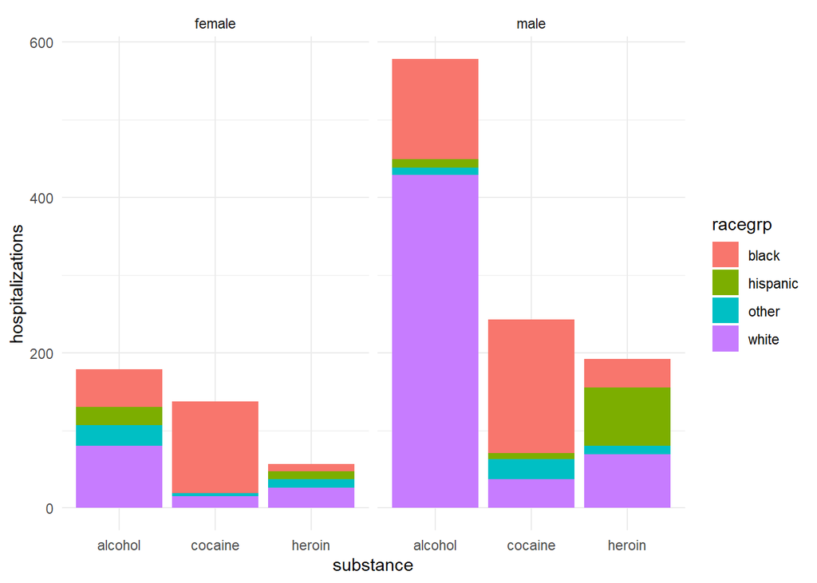

```r
ggplot(HELPrct) +
  aes(x = substance, y = hospitalizations, fill = racegrp) +
  geom_col() +
  scale_fill_hue(direction = 1) +
  theme_minimal() +
  facet_wrap(vars(sex))
```